# Lauren’s Spatial Regression

```r
packages<-c("cowplot", "dplyr", "geosphere", "ggplot2", "ggExtra", "maps", "maptools", "readxl", "rgdal", "rgeos", "sf", "sp", "spatialreg", "spdep", "tidyr", "viridis", "mapproj", "maps", "maptools", "spatialreg")
sapply(packages, require, character.only=T)
```

```
##    cowplot      dplyr  geosphere    ggplot2    ggExtra       maps
##       TRUE       TRUE       TRUE       TRUE       TRUE       TRUE
##   maptools     readxl      rgdal      rgeos         sf         sp
##       TRUE       TRUE       TRUE       TRUE       TRUE       TRUE
## spatialreg      spdep      tidyr    viridis    mapproj       maps
##       TRUE       TRUE       TRUE       TRUE       TRUE       TRUE
##   maptools spatialreg
##       TRUE       TRUE
```

```r
data <- read.csv('./Data/childpov18_southfull.csv',
                   colClasses = c("character", "character", "character",
                                  "numeric", "numeric", "numeric", "numeric",
                                  "numeric", "numeric", "numeric", "numeric",
                                  "numeric", "numeric", "numeric", "numeric",
                                  "numeric", "numeric", "numeric", "numeric",
                                  "numeric", "numeric", "numeric", "numeric",
                                  "numeric", "numeric", "numeric", "numeric",
                                  "numeric", "numeric", "numeric", "numeric",
                                  "numeric", "numeric", "numeric", "numeric"))
```

```r
names(data)[names(data)=="X2016.child.poverty"] <- "child.pov.2016"
```

# Analysis

```r
tn_pov <- data %>% subset(State == "TN")

summary(tn_pov)
```

```
##      FIPS              State           County_Name          Longitude
##  Length:95          Length:95          Length:95          Min.   :-89.90
##  Class :character   Class :character   Class :character   1st Qu.:-87.78
##  Mode  :character   Mode  :character   Mode  :character   Median :-86.06
##                                                           Mean   :-86.11
##                                                           3rd Qu.:-84.57
##                                                           Max.   :-81.85
##     Latitude     child.pov.2016  unemployment_13    per_lhs_13
##  Min.   :35.12   Min.   : 6.40   Min.   : 5.200   Min.   : 5.40
##  1st Qu.:35.52   1st Qu.:22.40   1st Qu.: 7.950   1st Qu.:16.30
##  Median :35.93   Median :28.00   Median : 9.200   Median :20.10
##  Mean   :35.89   Mean   :26.99   Mean   : 9.144   Mean   :20.01
##  3rd Qu.:36.29   3rd Qu.:30.90   3rd Qu.:10.400   3rd Qu.:23.75
##  Max.   :36.56   Max.   :43.60   Max.   :14.500   Max.   :29.50
##   per_black_13      per_hispanic_13    per_ag_13     per_construction_13
##  Min.   : 0.08343   Min.   : 0.000   Min.   :0.000   Min.   : 3.147
##  1st Qu.: 1.60283   1st Qu.: 1.610   1st Qu.:1.108   1st Qu.: 6.146
##  Median : 3.07232   Median : 2.262   Median :2.117   Median : 7.340
##  Mean   : 7.23064   Mean   : 3.024   Mean   :2.256   Mean   : 7.747
##  3rd Qu.: 8.23131   3rd Qu.: 3.815   3rd Qu.:2.892   3rd Qu.: 8.748
##  Max.   :52.04943   Max.   :11.390   Max.   :6.135   Max.   :17.267
##  per_manufacturing_13 per_retail_13    per_healthss_13 per_singlemom_13
##  Min.   : 6.302       Min.   : 5.719   Min.   :12.02   Min.   : 4.736
##  1st Qu.:13.351       1st Qu.:11.083   1st Qu.:19.81   1st Qu.: 7.405
##  Median :18.215       Median :12.192   Median :21.74   Median : 9.197
##  Mean   :17.546       Mean   :11.892   Mean   :22.09   Mean   : 9.310
##  3rd Qu.:21.433       3rd Qu.:12.852   3rd Qu.:24.12   3rd Qu.:10.778
##  Max.   :30.679       Max.   :17.230   Max.   :32.48   Max.   :20.445
##      urban            rural          lnchildpov    lnunemployment
##  Min.   :0.0000   Min.   :0.0000   Min.   :1.856   Min.   :1.649
##  1st Qu.:0.0000   1st Qu.:0.0000   1st Qu.:3.109   1st Qu.:2.073
##  Median :0.0000   Median :0.0000   Median :3.332   Median :2.219
##  Mean   :0.4421   Mean   :0.1684   Mean   :3.259   Mean   :2.195
##  3rd Qu.:1.0000   3rd Qu.:0.0000   3rd Qu.:3.431   3rd Qu.:2.342
##  Max.   :1.0000   Max.   :1.0000   Max.   :3.775   Max.   :2.674
##     lnlesshs        lnblack          lnhispanic           lnag
##  Min.   :1.686   Min.   :-2.4837   Min.   :-4.6052   Min.   :-4.6052
##  1st Qu.:2.791   1st Qu.: 0.4703   1st Qu.: 0.4760   1st Qu.: 0.1029
##  Median :3.001   Median : 1.1224   Median : 0.8164   Median : 0.7498
##  Mean   :2.961   Mean   : 1.1547   Mean   : 0.7808   Mean   : 0.5247
```

[output cut: 8 more lines]

```
##  Max.   :2.849   Max.   :3.424   Max.   :2.847   Max.   :3.481
##   lnsinglemom      lnchpov17      lnuninsured    lnincome_ratio
##  Min.   :1.555   Min.   :1.649   Min.   :2.100   Min.   :1.263
##  1st Qu.:2.002   1st Qu.:3.084   1st Qu.:2.766   1st Qu.:1.462
##  Median :2.219   Median :3.273   Median :2.817   Median :1.524
##  Mean   :2.189   Mean   :3.223   Mean   :2.816   Mean   :1.521
##  3rd Qu.:2.378   3rd Qu.:3.418   3rd Qu.:2.882   3rd Qu.:1.587
##  Max.   :3.018   Max.   :3.857   Max.   :3.094   Max.   :1.781
##  lnsevere_housing  lnteenbirth     lnunmarried
##  Min.   :2.135    Min.   :2.452   Min.   :0.010
##  1st Qu.:2.506    1st Qu.:3.780   1st Qu.:3.353
##  Median :2.616    Median :3.924   Median :3.555
##  Mean   :2.608    Mean   :3.910   Mean   :3.414
##  3rd Qu.:2.705    3rd Qu.:4.077   3rd Qu.:3.812
##  Max.   :3.073    Max.   :4.536   Max.   :4.240
```

```r
equation <- child.pov.2016 ~ rural + urban + lnmanufacturing + lnag +
            lnretail + lnhealthss + lnconstruction + lnlesshs +
            lnunemployment + lnsinglemom + lnblack + lnhispanic +
            lnuninsured + lnincome_ratio + lnteenbirth + lnunmarried

# limit units
options(scipen = 5)
```

```r
ols <- lm(equation, data=tn_pov)
summary(ols)
```

```
##
## Call:
## lm(formula = equation, data = tn_pov)
##
## Residuals:
##      Min       1Q   Median       3Q      Max
## -10.0085  -3.7189   0.1444   3.4090   9.6186
##
## Coefficients:
##                  Estimate Std. Error t value Pr(>|t|)
## (Intercept)     -45.27363   27.26962  -1.660  0.10088
## rural             2.49436    1.67045   1.493  0.13941
## urban            -1.99676    1.34131  -1.489  0.14061
## lnmanufacturing  -1.72317    2.15715  -0.799  0.42682
## lnag             -0.73468    0.75630  -0.971  0.33435
## lnretail         -4.76028    3.42410  -1.390  0.16841
## lnhealthss        4.33801    3.93941   1.101  0.27420
## lnconstruction    0.34696    2.26752   0.153  0.87878
## lnlesshs         12.01904    3.97210   3.026  0.00336 **
## lnunemployment    8.11971    3.83566   2.117  0.03746 *
## lnsinglemom       3.06607    2.20241   1.392  0.16784
## lnblack          -0.32650    0.46369  -0.704  0.48344
## lnhispanic        1.55752    0.70061   2.223  0.02910 *
## lnuninsured       0.23585    6.15331   0.038  0.96952
## lnincome_ratio    9.08924    6.16534   1.474  0.14444
## lnteenbirth      -0.03747    1.93299  -0.019  0.98458
## lnunmarried       0.09408    0.68154   0.138  0.89056
## ---
## Signif. codes:  0 '***' 0.001 '**' 0.01 '*' 0.05 '.' 0.1 ' ' 1
##
## Residual standard error: 4.656 on 78 degrees of freedom
## Multiple R-squared:  0.6105, Adjusted R-squared:  0.5306
## F-statistic: 7.641 on 16 and 78 DF,  p-value: 2.035e-10
```

P-values indicate that less than high school education, unemployment, and one race variable are significant.

# Contiguity Neighbors

```r
#Obtain FIPS Codes by county
fips <- county.fips

#Create county polygons
tnmap <- map(database = "county", regions = "tennessee", fill=T, plot=F)
IDs <- sub("^tnmap,","",tnmap$names)

#Add FIPS codes to the county polygons
fips.codes <- separate(data = fips, col = polyname, into = c("state", "county"), sep = ",")
tn_fips <- subset(fips.codes, state=="tennessee", select=fips)
names <- fips.codes$county
tn_IDs <- unique(tn_fips$fips)

#Create spatial polygons
tn_sp = map2SpatialPolygons(tnmap,tn_fips$fips,CRS("+proj=longlat"))
names(tn_sp@polygons) <- tn_IDs

#Create neighbor weights using the queens case
neighb.data <- poly2nb(tn_sp, queen=T)
names(neighb.data) <- names(tn_sp@polygons)

#Create list of neighbors
cont.neighb <- nb2listw(neighb.data,style="W", zero.policy = TRUE)
```

# Moran’s Correlation and LaGrange Multiplier Tests

```r
lm.morantest(ols, cont.neighb)
```

```
##
##  Global Moran I for regression residuals
##
## data:
## model: lm(formula = equation, data = tn_pov)
## weights: cont.neighb
##
## Moran I statistic standard deviate = 0.30616, p-value = 0.3797
## alternative hypothesis: greater
## sample estimates:
## Observed Moran I      Expectation         Variance
##     -0.016727910     -0.035356926      0.003702379
```

P-value is insignificant, therefore we fail to reject H0. (Right?)

```r
lm.LMtests(ols, cont.neighb, test="all")
```

```
##
##  Lagrange multiplier diagnostics for spatial dependence
##
## data:
## model: lm(formula = equation, data = tn_pov)
## weights: cont.neighb
##
## LMerr = 0.064508, df = 1, p-value = 0.7995
##
##
##  Lagrange multiplier diagnostics for spatial dependence
##
## data:
## model: lm(formula = equation, data = tn_pov)
## weights: cont.neighb
##
## LMlag = 0.00014823, df = 1, p-value = 0.9903
##
##
##  Lagrange multiplier diagnostics for spatial dependence
##
## data:
## model: lm(formula = equation, data = tn_pov)
## weights: cont.neighb
##
## RLMerr = 0.17369, df = 1, p-value = 0.6769
##
##
##  Lagrange multiplier diagnostics for spatial dependence
##
## data:
## model: lm(formula = equation, data = tn_pov)
## weights: cont.neighb
##
## RLMlag = 0.10933, df = 1, p-value = 0.7409
##
##
##  Lagrange multiplier diagnostics for spatial dependence
##
## data:
## model: lm(formula = equation, data = tn_pov)
## weights: cont.neighb
##
## SARMA = 0.17383, df = 2, p-value = 0.9168
```

Results: LMerr: 0.7995 LMlag: 0.9903 RLMerr: 0.6769 RLMlag: 0.7409 SARMA: 0.9168

# Spatial Lag Models

```r
SLX.model <- lmSLX(equation, data=tn_pov, cont.neighb)
summary(SLX.model)
```

```
##
## Call:
## lm(formula = formula(paste("y ~ ", paste(colnames(x)[-1], collapse = "+"))),
##     data = as.data.frame(x), weights = weights)
##
## Residuals:
##     Min      1Q  Median      3Q     Max
## -5.9744 -2.8088 -0.6231  2.4628 11.7117
##
## Coefficients:
##                     Estimate Std. Error t value Pr(>|t|)
## (Intercept)          44.4758    76.3670   0.582   0.5624
## rural                 4.5876     1.9235   2.385   0.0202 *
## urban                -3.3493     1.4704  -2.278   0.0262 *
## lnmanufacturing      -1.1436     2.5638  -0.446   0.6571
## lnag                  0.2857     0.8523   0.335   0.7386
## lnretail             -6.5983     3.9124  -1.686   0.0967 .
## lnhealthss           -3.2098     5.2442  -0.612   0.5427
## lnconstruction       -0.1881     2.4793  -0.076   0.9398
## lnlesshs             11.6993     4.5082   2.595   0.0118 *
## lnunemployment        2.1207     4.6408   0.457   0.6493
## lnsinglemom           4.4410     2.6314   1.688   0.0965 .
## lnblack               0.1466     0.5958   0.246   0.8064
## lnhispanic            1.9914     0.7998   2.490   0.0155 *
## lnuninsured          -2.7562     6.8918  -0.400   0.6906
## lnincome_ratio        5.5700     6.8615   0.812   0.4200
## lnteenbirth          -0.2871     2.0076  -0.143   0.8867
## lnunmarried           0.1743     0.7279   0.239   0.8116
## lag.rural             1.3728     5.9499   0.231   0.8183
## lag.urban             5.1632     3.3980   1.519   0.1337
## lag.lnmanufacturing  -2.2403     6.0278  -0.372   0.7114
## lag.lnag             -0.1665     2.1768  -0.076   0.9393
## lag.lnretail         -4.4277    10.2587  -0.432   0.6675
## lag.lnhealthss        5.5047     9.2221   0.597   0.5527
## lag.lnconstruction   -1.8422     6.7131  -0.274   0.7847
## lag.lnlesshs          6.9237    11.0930   0.624   0.5348
## lag.lnunemployment   10.5098     9.7287   1.080   0.2842
## lag.lnsinglemom     -11.7535     7.1072  -1.654   0.1032
## lag.lnblack          -0.7273     1.0587  -0.687   0.4946
## lag.lnhispanic        3.7197     2.3965   1.552   0.1257
## lag.lnuninsured     -24.7010    16.6952  -1.480   0.1441
## lag.lnincome_ratio   23.3186    16.0412   1.454   0.1511
## lag.lnteenbirth      -5.9681     5.4783  -1.089   0.2802
## lag.lnunmarried       0.1962     2.1212   0.093   0.9266
## ---
## Signif. codes:  0 '***' 0.001 '**' 0.01 '*' 0.05 '.' 0.1 ' ' 1
##
## Residual standard error: 4.455 on 62 degrees of freedom
## Multiple R-squared:  0.7165, Adjusted R-squared:  0.5701
## F-statistic: 4.896 on 32 and 62 DF,  p-value: 0.00000004515
```

Lagged variables were not significant. Maybe an error model would be better? Let’s get a closer look:

```r
summary(impacts(SLX.model, cont.neighb), zstats = TRUE)[["pzmat"]]
```

```
##                      Direct   Indirect     Total
## rural           0.017081081 0.81753216 0.3868832
## urban           0.022736003 0.12864366 0.6035683
## lnmanufacturing 0.655567822 0.71014946 0.5518272
## lnag            0.737451710 0.93904123 0.9609031
## lnretail        0.091702868 0.66602913 0.3668511
## lnhealthss      0.540503317 0.55057552 0.8037178
## lnconstruction  0.939515508 0.78375615 0.7770909
## lnlesshs        0.009455787 0.53252959 0.1352550
## lnunemployment  0.647698594 0.28001497 0.1687747
## lnsinglemom     0.091472452 0.09818162 0.3702031
## lnblack         0.805614384 0.49207320 0.5970796
## lnhispanic      0.012778591 0.12062856 0.0399841
## lnuninsured     0.689214080 0.13899978 0.1506990
## lnincome_ratio  0.416919696 0.14603776 0.1097439
## lnteenbirth     0.886271480 0.27597675 0.3144261
## lnunmarried     0.810796561 0.92629695 0.8780403
```

```r
sp.lag.model <- spatialreg::lagsarlm(equation, data=tn_pov, cont.neighb)
summary(sp.lag.model, Nagelkerke = TRUE)
```

```
##
## Call:
## spatialreg::lagsarlm(formula = equation, data = tn_pov, listw = cont.neighb)
##
## Residuals:
##       Min        1Q    Median        3Q       Max
## -10.01157  -3.71403   0.14327   3.40961   9.62333
##
## Type: lag
## Coefficients: (asymptotic standard errors)
##                   Estimate Std. Error z value  Pr(>|z|)
## (Intercept)     -45.271645  24.710842 -1.8321 0.0669431
## rural             2.495698   1.515159  1.6472 0.0995267
## urban            -1.995773   1.229360 -1.6234 0.1044987
## lnmanufacturing  -1.725016   1.959384 -0.8804 0.3786498
## lnag             -0.734969   0.688911 -1.0669 0.2860368
## lnretail         -4.758142   3.105027 -1.5324 0.1254238
## lnhealthss        4.327755   3.609746  1.1989 0.2305635
## lnconstruction    0.345726   2.055835  0.1682 0.8664511
## lnlesshs         12.018169   3.600358  3.3380 0.0008437
## lnunemployment    8.109287   3.504411  2.3140 0.0206665
## lnsinglemom       3.068910   1.995981  1.5375 0.1241600
## lnblack          -0.325773   0.420657 -0.7744 0.4386716
## lnhispanic        1.557640   0.639334  2.4363 0.0148365
## lnuninsured       0.243303   5.578465  0.0436 0.9652115
## lnincome_ratio    9.074587   5.645100  1.6075 0.1079413
## lnteenbirth      -0.035418   1.753664 -0.0202 0.9838866
## lnunmarried       0.093437   0.623042  0.1500 0.8807888
##
## Rho: 0.0017055, LR test value: 0.00016767, p-value: 0.98967
## Asymptotic standard error: 0.1238
##     z-value: 0.013776, p-value: 0.98901
## Wald statistic: 0.00018979, p-value: 0.98901
##
## Log likelihood: -271.5515 for lag model
## ML residual variance (sigma squared): 17.796, (sigma: 4.2186)
## Nagelkerke pseudo-R-squared: 0.6105
## Number of observations: 95
## Number of parameters estimated: 19
## AIC: 581.1, (AIC for lm: 579.1)
## LM test for residual autocorrelation
## test value: 0.17282, p-value: 0.67762
```

P-value = 0.98967 Not significant. Let’s move on to an error model.

# Spatial Error Models

```r
sp.err.model <- spatialreg::errorsarlm(equation, data=tn_pov, cont.neighb)
summary(sp.err.model, Nagelkerke = TRUE)
```

```
##
## Call:
## spatialreg::errorsarlm(formula = equation, data = tn_pov, listw = cont.neighb)
##
## Residuals:
##        Min         1Q     Median         3Q        Max
## -10.157627  -3.709943   0.093012   3.398218   9.551531
##
## Type: error
## Coefficients: (asymptotic standard errors)
##                   Estimate Std. Error z value  Pr(>|z|)
## (Intercept)     -45.671244  24.557247 -1.8598 0.0629157
## rural             2.467613   1.521403  1.6219 0.1048178
## urban            -1.876155   1.206592 -1.5549 0.1199650
## lnmanufacturing  -1.700022   1.930456 -0.8806 0.3785169
## lnag             -0.775240   0.683911 -1.1335 0.2569881
## lnretail         -4.751816   3.110132 -1.5279 0.1265497
## lnhealthss        4.501687   3.523532  1.2776 0.2013882
## lnconstruction    0.379970   2.041995  0.1861 0.8523839
## lnlesshs         12.112859   3.588309  3.3756 0.0007364
## lnunemployment    8.447091   3.416802  2.4722 0.0134276
## lnsinglemom       2.906418   1.998163  1.4545 0.1457953
## lnblack          -0.352383   0.413379 -0.8524 0.3939680
## lnhispanic        1.608086   0.637186  2.5237 0.0116116
## lnuninsured      -0.125572   5.574434 -0.0225 0.9820280
## lnincome_ratio    9.389092   5.568430  1.6861 0.0917710
## lnteenbirth      -0.120564   1.753887 -0.0687 0.9451958
## lnunmarried       0.074619   0.619348  0.1205 0.9041028
##
## Lambda: -0.06587, LR test value: 0.10445, p-value: 0.74655
## Asymptotic standard error: 0.16305
##     z-value: -0.40399, p-value: 0.68622
## Wald statistic: 0.16321, p-value: 0.68622
##
## Log likelihood: -271.4993 for error model
## ML residual variance (sigma squared): 17.762, (sigma: 4.2145)
## Nagelkerke pseudo-R-squared: 0.61093
## Number of observations: 95
## Number of parameters estimated: 19
## AIC: 581, (AIC for lm: 579.1)
```

Significant variables: Less than high school education, unemployment, and percent of the population that is hispanic.

# Comparing Models

SLX Model  
Adj-R2: 0.5701  
p-value: 0.00000004515

Lag Model  
R2: 0.6105  
p-value: 0.98967

Err Model  
R2: 0.61093  
p-value: 0.74655

This indicates that our spatial error model most likely fits best. Let’s test it.

```r
spatialreg::Hausman.test(sp.err.model)
```

```
##
##  Spatial Hausman test (asymptotic)
##
## data:  NULL
## Hausman test = 13.062, df = 17, p-value = 0.732
```

Based on the p-value of 0.732 we would not reject the HO that the estimation method should yield coefficients appropriate for a spatial error model.

```r
sd.err <- spatialreg::errorsarlm(equation, tn_pov, cont.neighb, etype = "emixed")
sdm <- spatialreg::lagsarlm(equation, tn_pov, cont.neighb, type = "mixed")

summary(sd.err, Nagelkerke = TRUE)
```

```
##
## Call:
## spatialreg::errorsarlm(formula = equation, data = tn_pov, listw = cont.neighb,
##     etype = "emixed")
##
## Residuals:
##      Min       1Q   Median       3Q      Max
## -7.07277 -2.57457 -0.44646  2.64201 10.94158
##
## Type: error
## Coefficients: (asymptotic standard errors)
##                       Estimate Std. Error z value  Pr(>|z|)
## (Intercept)          63.648758  47.257546  1.3468 0.1780290
## rural                 4.887974   1.452933  3.3642 0.0007676
## urban                -3.501743   1.191172 -2.9397 0.0032848
## lnmanufacturing      -0.789172   2.106130 -0.3747 0.7078819
## lnag                  0.403084   0.671416  0.6003 0.5482736
## lnretail             -6.474819   3.051933 -2.1215 0.0338758
## lnhealthss           -5.139603   4.456152 -1.1534 0.2487575
## lnconstruction        0.034356   2.015037  0.0170 0.9863970
## lnlesshs             11.019220   3.559571  3.0957 0.0019638
## lnunemployment       -0.397748   3.798050 -0.1047 0.9165946
## lnsinglemom           4.566899   2.052171  2.2254 0.0260545
## lnblack               0.286496   0.502682  0.5699 0.5687219
## lnhispanic            1.984550   0.602234  3.2953 0.0009831
## lnuninsured          -1.238155   5.479614 -0.2260 0.8212351
## lnincome_ratio        5.278291   5.449431  0.9686 0.3327473
## lnteenbirth           0.178511   1.577152  0.1132 0.9098833
## lnunmarried           0.160712   0.573939  0.2800 0.7794649
## lag.rural            -0.228663   4.455743 -0.0513 0.9590716
## lag.urban             4.990241   2.372514  2.1034 0.0354347
## lag.lnmanufacturing  -2.521913   4.570061 -0.5518 0.5810624
## lag.lnag              0.238695   1.621544  0.1472 0.8829721
## lag.lnretail         -2.546304   7.553732 -0.3371 0.7360474
## lag.lnhealthss        6.014359   7.149899  0.8412 0.4002465
## lag.lnconstruction   -2.738076   5.181779 -0.5284 0.5972185
## lag.lnlesshs          3.788204   8.224909  0.4606 0.6451021
## lag.lnunemployment   13.511644   6.870656  1.9666 0.0492325
## lag.lnsinglemom     -11.037771   5.195410 -2.1245 0.0336264
## lag.lnblack          -0.980855   0.742745 -1.3206 0.1866412
## lag.lnhispanic        2.204447   1.782311  1.2368 0.2161436
## lag.lnuninsured     -24.016554  12.345328 -1.9454 0.0517273
## lag.lnincome_ratio   20.201372  12.187292  1.6576 0.0974029
## lag.lnteenbirth      -9.906611   3.748303 -2.6430 0.0082185
## lag.lnunmarried       1.300762   1.557005  0.8354 0.4034781
##
## Lambda: -0.55235, LR test value: 5.334, p-value: 0.020913
## Asymptotic standard error: 0.16893
##     z-value: -3.2696, p-value: 0.0010769
## Wald statistic: 10.69, p-value: 0.0010769
##
## Log likelihood: -253.8006 for error model
## ML residual variance (sigma squared): 11.569, (sigma: 3.4013)
## Nagelkerke pseudo-R-squared: 0.73195
## Number of observations: 95
## Number of parameters estimated: 35
## AIC: 577.6, (AIC for lm: 580.94)
```

```r
summary(spatialreg::impacts(sd.err, listw = cont.neighb, R = 100), zstats = TRUE)[["pzmat"]]
```

```
##                       Direct    Indirect      Total
## rural           0.0007676255 0.959071637 0.33077106
## urban           0.0032848222 0.035434684 0.48449619
## lnmanufacturing 0.7078819133 0.581062433 0.37142337
## lnag            0.5482736387 0.882972125 0.68997883
## lnretail        0.0338758260 0.736047445 0.27265472
## lnhealthss      0.2487575318 0.400246548 0.88001908
## lnconstruction  0.9863970282 0.597218485 0.58459165
## lnlesshs        0.0019637592 0.645102124 0.06638862
## lnunemployment  0.9165946329 0.049232503 0.01954369
## lnsinglemom     0.0260544827 0.033626394 0.22630372
## lnblack         0.5687219033 0.186641236 0.27864845
## lnhispanic      0.0009831084 0.216143601 0.02816522
## lnuninsured     0.8212351454 0.051727318 0.04263533
## lnincome_ratio  0.3327473134 0.097402922 0.03271517
## lnteenbirth     0.9098833198 0.008218492 0.01146763
## lnunmarried     0.7794648890 0.403478099 0.35579975
```

Based on the impacts analysis, we can see not many of the impacts are significant, so we might consider limiting the model to either the spatial error, SLX, or OLS models.

# Comparing Spatial-Durbin to the other models

```r
spatialreg::LR.sarlm(sd.err,sp.err.model)
```

```
##
##  Likelihood ratio for spatial linear models
##
## data:
## Likelihood ratio = 35.397, df = 16, p-value = 0.003505
## sample estimates:
##       Log likelihood of sd.err Log likelihood of sp.err.model
##                      -253.8006                      -271.4993
```

```r
spatialreg::LR.sarlm(sd.err,SLX.model)
```

```
##
##  Likelihood ratio for spatial linear models
##
## data:
## Likelihood ratio = 5.334, df = 1, p-value = 0.02091
## sample estimates:
##    Log likelihood of sd.err Log likelihood of SLX.model
##                   -253.8006                   -256.4677
```

```r
spatialreg::LR.sarlm(sd.err,ols)
```

```
##
##  Likelihood ratio for spatial linear models
##
## data:
## Likelihood ratio = 35.502, df = 17, p-value = 0.005342
## sample estimates:
## Log likelihood of sd.err    Log likelihood of ols
##                -253.8006                -271.5515
```

# K-Neighbors (AKA OK BOOMER)

```r
all.xy <- centroid(tn_sp)
#tx_IDs <- unique(tx_fips$fips) this value was created in the contiguity section but would be needed here if only using distance functions. See "creating list of contiguity neighbors" for details.
rownames(all.xy) <- tn_IDs
colnames(all.xy) <- cbind("x","y")
```

```r
#Create neighbors
all.dist.k1 <- knn2nb(knearneigh(all.xy, k=1, longlat = TRUE))
all.dist.k3 <- knn2nb(knearneigh(all.xy, k=3, longlat = TRUE))
all.dist.k5 <- knn2nb(knearneigh(all.xy, k=5, longlat = TRUE))

#Determine max k distance value to neighbor
all.max.k1 <- max(unlist(nbdists(all.dist.k1, all.xy, longlat=TRUE)))
all.max.k3 <- max(unlist(nbdists(all.dist.k3, all.xy, longlat=TRUE)))
all.max.k5 <- max(unlist(nbdists(all.dist.k5, all.xy, longlat=TRUE)))

#Calculate neighbors based on distance
all.sp.dist.k1 <- dnearneigh(all.xy, d1=0, d2=1 * all.max.k1, longlat = TRUE)
all.sp.dist.k3 <- dnearneigh(all.xy, d1=0, d2=1 * all.max.k3, longlat = TRUE)
all.sp.dist.k5 <- dnearneigh(all.xy, d1=0, d2=1 * all.max.k5, longlat = TRUE)

#Create neighbor list
all.dist.neighb.k1 <- nb2listw(all.sp.dist.k1,style="W", zero.policy = TRUE)
all.dist.neighb.k3 <- nb2listw(all.sp.dist.k3,style="W", zero.policy = TRUE)
all.dist.neighb.k5 <- nb2listw(all.sp.dist.k5,style="W", zero.policy = TRUE)
```

# Distance Lag Model

```r
all.dist.lag.k1 <- lagsarlm(equation, data = tn_pov, listw = all.dist.neighb.k1)
all.dist.lag.k3 <- lagsarlm(equation, data = tn_pov, listw = all.dist.neighb.k3)
all.dist.lag.k5 <- lagsarlm(equation, data = tn_pov, listw = all.dist.neighb.k5)
```

```r
summary(all.dist.lag.k1, Nagelkerke = TRUE)
```

```
##
## Call:spatialreg::lagsarlm(formula = formula, data = data, listw = listw,
##     na.action = na.action, Durbin = Durbin, type = type, method = method,
##     quiet = quiet, zero.policy = zero.policy, interval = interval,
##     tol.solve = tol.solve, trs = trs, control = control)
##
## Residuals:
##        Min         1Q     Median         3Q        Max
## -10.020439  -3.649269   0.058279   3.420685   9.691537
##
## Type: lag
## Coefficients: (asymptotic standard errors)
##                   Estimate Std. Error z value  Pr(>|z|)
## (Intercept)     -45.030132  24.697086 -1.8233 0.0682584
## rural             2.500475   1.513583  1.6520 0.0985297
## urban            -1.973530   1.216325 -1.6225 0.1046888
## lnmanufacturing  -1.760348   1.961564 -0.8974 0.3694944
## lnag             -0.739224   0.685166 -1.0789 0.2806337
## lnretail         -4.710761   3.107886 -1.5157 0.1295840
## lnhealthss        4.203843   3.573576  1.1764 0.2394476
## lnconstruction    0.313717   2.054318  0.1527 0.8786262
## lnlesshs         11.986353   3.598527  3.3309 0.0008656
## lnunemployment    7.889390   3.537187  2.2304 0.0257200
## lnsinglemom       3.144750   1.998081  1.5739 0.1155140
## lnblack          -0.311966   0.419944 -0.7429 0.4575580
## lnhispanic        1.549904   0.634965  2.4409 0.0146496
## lnuninsured       0.427609   5.574848  0.0767 0.9388596
## lnincome_ratio    8.698579   5.624714  1.5465 0.1219857
## lnteenbirth      -0.048781   1.750747 -0.0279 0.9777715
## lnunmarried       0.101960   0.617330  0.1652 0.8688164
##
## Rho: 0.025919, LR test value: 0.080255, p-value: 0.77695
## Asymptotic standard error: 0.087941
##     z-value: 0.29473, p-value: 0.7682
## Wald statistic: 0.086867, p-value: 0.7682
##
## Log likelihood: -271.5114 for lag model
## ML residual variance (sigma squared): 17.777, (sigma: 4.2163)
## Nagelkerke pseudo-R-squared: 0.61083
## Number of observations: 95
## Number of parameters estimated: 19
## AIC: 581.02, (AIC for lm: 579.1)
## LM test for residual autocorrelation
## test value: 1.3346, p-value: 0.24799
```

# Distance Error Model

```r
all.dist.err.k1 <- errorsarlm(equation, data = tn_pov, listw = all.dist.neighb.k1)
all.dist.err.k3 <- errorsarlm(equation, data = tn_pov, listw = all.dist.neighb.k3)
all.dist.err.k5 <- errorsarlm(equation, data = tn_pov, listw = all.dist.neighb.k5)
```

```r
summary(all.dist.err.k1, Nagelkerke = TRUE)
```

```
##
## Call:
## spatialreg::errorsarlm(formula = formula, data = data, listw = listw,
##     na.action = na.action, Durbin = Durbin, etype = etype, method = method,
##     quiet = quiet, zero.policy = zero.policy, interval = interval,
##     tol.solve = tol.solve, trs = trs, control = control)
##
## Residuals:
##       Min        1Q    Median        3Q       Max
## -10.24709  -3.66196   0.18246   3.39547   9.55859
##
## Type: error
## Coefficients: (asymptotic standard errors)
##                   Estimate Std. Error z value Pr(>|z|)
## (Intercept)     -48.070798  24.395689 -1.9705 0.048785
## rural             2.426009   1.511183  1.6054 0.108412
## urban            -1.936839   1.204479 -1.6080 0.107829
## lnmanufacturing  -1.725119   1.910678 -0.9029 0.366588
## lnag             -0.759012   0.683219 -1.1109 0.266596
## lnretail         -4.620239   3.097900 -1.4914 0.135854
## lnhealthss        4.916792   3.494465  1.4070 0.159421
## lnconstruction    0.446796   2.016517  0.2216 0.824650
## lnlesshs         12.397568   3.584074  3.4591 0.000542
## lnunemployment    8.320623   3.389766  2.4546 0.014103
## lnsinglemom       2.935867   1.983624  1.4801 0.138859
## lnblack          -0.397321   0.412960 -0.9621 0.335985
## lnhispanic        1.653547   0.630920  2.6208 0.008771
## lnuninsured      -0.579823   5.570575 -0.1041 0.917101
## lnincome_ratio    9.972491   5.502469  1.8124 0.069930
## lnteenbirth       0.045680   1.747911  0.0261 0.979150
## lnunmarried       0.046582   0.617896  0.0754 0.939906
##
## Lambda: -0.08757, LR test value: 0.41959, p-value: 0.51714
## Asymptotic standard error: 0.11598
##     z-value: -0.75504, p-value: 0.45022
## Wald statistic: 0.57009, p-value: 0.45022
##
## Log likelihood: -271.3418 for error model
## ML residual variance (sigma squared): 17.67, (sigma: 4.2036)
## Nagelkerke pseudo-R-squared: 0.61222
## Number of observations: 95
## Number of parameters estimated: 19
## AIC: 580.68, (AIC for lm: 579.1)
```

Comparing the two: Dis. Lag: R2: 0.61083 P-value: 0.77695 AIC: 581.02 Dis. Error: R2: 0.61222 P-value: 0.51714 AIC: 580.68 While the two models are relatively comparable, we can see that again the error model is generally a better fit for the dataset.

# Mapping the Models

```r
dist.err.data <- summary(all.dist.err.k1, correlation=TRUE, Nagelkerke = TRUE)

dist.err.output <- cbind.data.frame(tn_pov$FIPS,
                               dist.err.data$fitted.values,
                               dist.err.data$residual,
                               tn_pov$child.pov.2016,
                               tn_pov$lnsinglemom,
                               tn_pov$lnuninsured,
                               tn_pov$lnlesshs,
                               tn_pov$lnincome_ratio,
                               stringsAsFactors = FALSE)

#Renaming columns
colnames(dist.err.output) <- c("fips","fitted","resid","childpov",
                               "single_mom","uninsured","less_hs","income_ratio")
```

```r
#Create quantiles
quantiles_sm <- dist.err.output %>%
  pull(single_mom) %>%
  quantile(probs = seq(0, 1, length.out = 4), na.rm = TRUE)

quantiles_pov <- dist.err.output %>%
  pull(childpov) %>%
  quantile(probs = seq(0, 1, length.out = 4), na.rm = TRUE)

#Create ranks
sm_rank <- cut(dist.err.output$single_mom,
               breaks= quantiles_sm,
               labels=c("1", "2", "3"),
               na.rm = TRUE,
               include.lowest = TRUE)

pov_rank <- cut(dist.err.output$childpov,
                breaks= quantiles_pov,
                labels=c("1", "2", "3"),
                na.rm = TRUE,
                include.lowest = TRUE)

#Join ranks and combined column to dataset
dist.err.output$mom_score <- as.numeric(sm_rank)
dist.err.output$pov_score <- as.numeric(pov_rank)
dist.err.output$mom_pov <- paste(as.numeric(dist.err.output$pov_score),
                         "-",
                         as.numeric(dist.err.output$mom_score))
```

```r
legend_colors <- tibble(
  x = c(3,2,1,3,2,1,3,2,1),
  y = c(3,3,3,2,2,2,1,1,1),
  z = c("#574249", "#627f8c", "#64acbe", "#985356", "#ad9ea5", "#b0d5df", "#c85a5a", "#e4acac", "#e8e8e8"))

xlabel <- "Poverty,Low \u2192 High"
xlabel <- gsub(",", "\n", xlabel)
ylabel <- "Single Mother Household,Low \u2192 High"
ylabel <- gsub(",", "\n", ylabel)

legend <- ggplot(legend_colors, aes(x,y)) +
  geom_tile(aes(fill=z)) +
  theme_minimal() + theme(legend.position = "none") +
  theme(panel.grid.major = element_blank(), panel.grid.minor = element_blank()) +
  theme(axis.text.x=element_blank(),
        axis.ticks.x=element_blank(),
        axis.text.y=element_blank(),
        axis.ticks.y=element_blank()) +
  labs(x = xlabel, y = ylabel) +
  scale_fill_identity() +
  ggtitle("Legend") +
  theme(axis.title.y = element_text(face = "italic", hjust = 0.5, size = 8)) +
  theme(axis.title.x = element_text(face = "italic", hjust = 0.5, size = 8)) +
  theme(plot.title = element_text(face="bold", hjust = 0.5, size = 10))
```

```r
world <- map_data("world")
states <- map_data("state")
counties <- map_data("county")

counties$polyname <- paste(counties$region, counties$subregion, sep = ",")
counties <- counties %>% left_join(fips, by = c("polyname" = "polyname"))
counties$fips <- as.character(counties$fips)
counties <- counties %>% left_join(tn_pov, by = c("fips" = "FIPS"))

southern_states <- subset(states, region %in%
                            c("texas", "arkansas", "louisiana", "mississippi",
                              "alabama", "georgia", "florida", "north carolina",
                              "south carolina", "tennessee", "oklahoma",
                              "kentucky", "west virginia", "virginia",
                              "maryland", "delaware", "district of columbia"))

southern_counties <- subset(counties, region %in%
                              c("texas", "arkansas", "louisiana", "mississippi",
                                "alabama", "georgia", "florida", "north carolina",
                                "south carolina", "tennessee", "oklahoma",
                                "kentucky", "west virginia", "virginia",
                                "maryland", "delaware", "district of columbia"))

tenn_counties <- subset(southern_counties, region == "tennessee")
```

```r
#Attach the data via the FIPS column and fortify the polygon
tn_poly <- tenn_counties %>%
  left_join(dist.err.output, by = c("fips" = "fips")) %>%
  fortify

#Add custom color scheme based on ranks
bivariate_color_scale <- tibble(
  "3 - 3" = "#574249",
  "2 - 3" = "#627f8c",
  "1 - 3" = "#64acbe",
  "3 - 2" = "#985356",
  "2 - 2" = "#ad9ea5",
  "1 - 2" = "#b0d5df",
  "3 - 1" = "#c85a5a",
  "2 - 1" = "#e4acac",
  "1 - 1" = "#e8e8e8") %>%
  gather("group", "fill")

tn_poly <- tn_poly %>%
  left_join(bivariate_color_scale, by = c("mom_pov" = "group"))
```

```r
mom_pov_map <- ggplot() +
  geom_polygon(data = world, aes(x=long,y=lat, group=group), fill = "gray95", color = "white") +
  geom_polygon(data = states, aes(x=long,y=lat, group=group), fill = "gray", color = "white") +
  geom_polygon(data = tn_poly, aes(x=long, y=lat, group=group, fill = fill)) +
  geom_polygon(data = southern_states, aes(x=long,y=lat, group=group), fill = NA, color = "white") +
  geom_polygon(data = tenn_counties, aes(x=long,y=lat, group=group), fill = NA, color = "black", size = 0.05) +
  coord_map("conic", lat0 = 35, xlim=c(-93,-80), ylim=c(30,40)) +
  scale_fill_identity() +
  theme_grey() + theme(legend.position="bottom") + theme(legend.title.align=0.5) +
  theme(panel.background = element_rect(fill = 'deepskyblue'),
        panel.grid.major = element_line(colour = NA)) +
  labs(x = "Longitude", y = "Latitude", fill = "Child Poverty",
       title = "Bivariate Map of Child Poverty and Single Mother Households") +
  theme(plot.title = element_text(face = "bold", hjust = 0.5))
#mom_pov_map use to preview the map
```

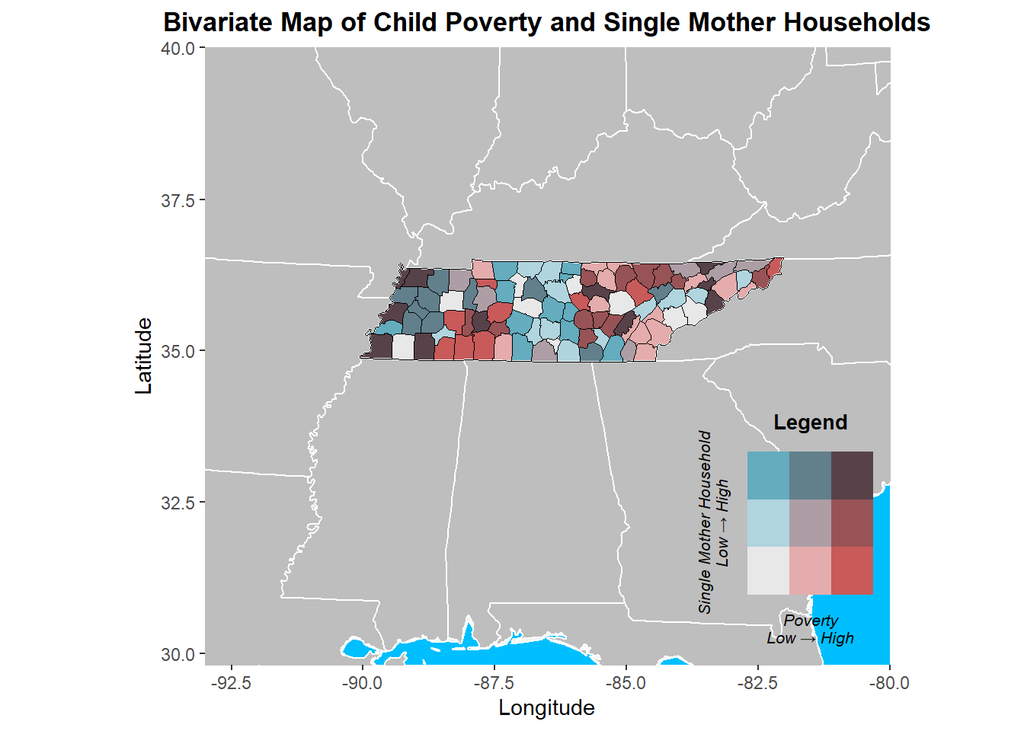

```r
final_map <- ggdraw() +
  draw_plot(mom_pov_map, x = 0, y = 0, width = 1, height = 1) +
  draw_plot(legend, x = 0.67, y = 0.10, width = 0.2, height = 0.35)

final_map
```